# Repguide user’s guide

David Brocks

2019-02-07

# Introduction

CRISPR-Cas9 (Clustered Regularly Interspaced Short Palindromic Repeats) nucleases have become the method of choice for genome editing and modulation of gene expression.

## guideRNA scoring

We further score the impact of predicted genomic off-target sites by their basepair distance to the nearest cis-regulatory element (*cis*):
$$S_{cis} = {Top} + \frac{(Bottom - Top)}{1 + exp(\frac{V50 - cis}{Slope\times100})}$$
This equation describes the Boltzmann sigmoid function, where V50 is the basepair distance at which the score is halfway between Top (1) and Bottom (0.1) (2kb by default) and slope represents the steepness of the sigmoid curve (5 by default). The final off-target score for a predicted off-target binding site is defined as the product of both scores:
$$S_{off} = S_{bind}\times S_{cis}$$
while the on target score of an on-target binding site is simply defined as:
$$S_{on} = S_{bind}$$
We then summarise the on- and off-target scores for a guide (*Sguide_off* and *Sguide_on*) over all predicted off- and on-target binding sites (Soff and Son) by first calculating the maximal score of a locus *l* and guide *g*:
$$Slocus_{on}(l,g) = \max_{b\in B_{l}} S_{on}$$
$$Slocus_{off}(l,g) = \max_{b\in B_{l}} S_{off}$$
where *Bl* is the set of all the on/off-target binding sites of locus *l*. A Locus is defined as either the full-length transposon interval (variable size) or a genomic bin of size 250 bps by default. The total off- and on-target score of a guide is then simply defined as:
$$Sguide_{on}(g) = \sum\limits_{l\in L_{on}} Slocus_{on}(l,g)$$
$$Sguide_{off}(g) = \sum\limits_{l\in L_{off}} Slocus_{off}(l,g)$$
Similarly, off- and on-target scores for combinations of guides (*Scomb*) are summarized for each locus l and guide g:
$$Scomb_{off}(c) = \sum\limits_{l\in L_{off}} \max_{g\in G} Slocus_{off}(l,g)$$
$$Scomb_{on}(c) = \sum\limits_{l\in L_{on}} \max_{g\in G} Slocus_{on}(l,g)$$

# Workflow

In this tutorial, we are going to design guideRNAs against long terminal repeats (LTRs) originating from the human endogenous retrovirus 9. By following this workflow, you will understand the basic steps of the Repguide package and learn how to adapt them to your custom requirements.

## Getting started

### Genome assembly

Repguide requires the genome assembly of your organism of choice stored as a *BSgenome* object. You can retrieve the full list of available *BSgenome* objects by typing `BSgenome::available.genomes()` or create and install a custom *BSgenome* object following the instructions of the *BSgenome* vignette.

Since we are designing guideRNAs against LTRs of the human genome, we will first install the UCSC hg38 assembly.

```r
if (!requireNamespace("BiocManager", quietly = TRUE))
    install.packages("BiocManager")
BiocManager::install("BSgenome.Hsapiens.UCSC.hg38")
```

To load Repguide and the human hg38 *BSgenome* into your R environment type:

```r
#library(Repguide)
devtools::load_all('/home/davidbr/src/Repguide', export_all = FALSE)
devtools::load_all('/home/davidbr/src/guideR.data')
library(BSgenome.Hsapiens.UCSC.hg38)
```

### Genome annotation

In addition to the assembled genome sequence, Repguide requires genomic coordinates of transposable elements (mandatory) and cis regulatory features (optional). A convient solution is to download transposon coordinates using the [UCSC table browser](https://genome.ucsc.edu/cgi-bin/hgTables) by selecting your genome of choice, group = Repeats, track = RepeatMasker, and output format = all fields from selected table. You can provide other annotation as long as it provides the basic information about chromosome, start, end, strand, and a transposon identifier (e.g. repname). In this tutorial, we will show you how to import such information using the provided example datasets.

### Bowtie aligner

Example naming of the human hg38 bowtie indeces:

- BSgenome.Hsapiens.UCSC.hg38.1.ebwt
- BSgenome.Hsapiens.UCSC.hg38.2.ebwt
- BSgenome.Hsapiens.UCSC.hg38.3.ebwt (not required)
- BSgenome.Hsapiens.UCSC.hg38.4.ebwt (not required)
- BSgenome.Hsapiens.UCSC.hg38.rev.1.ebwt
- BSgenome.Hsapiens.UCSC.hg38.rev.2.ebwt

## Creating a guideSet

We start the workflow by creating a *guideSet* object, which is a S4 class to store genomic information and the results of later functions.

To create a new *guideSet* object, we have to define the genome assembly and provide annotation on transposable elements and cis regulatory features (e.g. promoters/enhancers) which is optional but highly recommended for optimal guideRNA design. In this tutorial, we will use the hg38 UCSC repeatmasker and FANTOM5 TSS annotation provided with the Repguide package.

```r
Sys.time()
```

```
#> [1] "2019-02-07 18:25:13 IST"
```

```r
# Path to FANTOM5 hg38 TSS bed file (provided)
tss_path <- system.file(package = 'Repguide', 'extdata', 'hg38_fair+new_CAGE_peaks_phase1and2.bed.gz')
# Path to RepeatMasker hg38 repeat annotation(provided)
repeats_path <- system.file(package = 'Repguide', 'extdata', 'hg38_ucsc_rmsk_ltr.txt.gz')
# Path to bowtie index directory (not provided)
index_dir <- system.file(package = 'Repguide', 'bowtie_indeces')

gs <- createGuideSet(genome = Hsapiens, # Hsapiens is the short version of BSgenome.Hsapiens.UCSC.hg38
                     tes = repeats_path, # can be either path to file or GRanges object)
                     cis = tss_path,  # can be either path to file or GRanges object)
                     refdir = index_dir) # will create bowtie indeces here if doesn't exist
```

```
#> Created new guideSet at Thu Feb  7 18:25:18 2019
```

```r
gs
```

```
#> guideSet object of BSgenome.Hsapiens.UCSC.hg38
#> with 0 targets
#> with 0 guides
#> with 0 combinations
#> with 0 QC plots
#> with 67 registered cores
#> matching bowtie index found: TRUE
```

## Adding target loci

To add target sites to our previously created *guideSet*, we can either provide the names of the repeat families we wish to target or a GRanges object with coordinates of the transposable elements.

To get the full list of available repeat families (including simple repeats) we can type `listFamilies(gs, low_complexity = TRUE)`.

The LTRs originating from the human endogenous retrovirus 9 all conveniently share a common ‘LTR12’ prefix (Note: The *Dfam* database allows open access to transposon genetic relationships, e.g. http://dfam.org/entry/DF0000399/relationships), allowing us to retrieve all its members by using a simple grep command:

```r
families <- grep('LTR12', listFamilies(gs), value = TRUE)
families
```

```
#> [1] "LTR12"  "LTR12_" "LTR12B" "LTR12C" "LTR12D" "LTR12E" "LTR12F"
```

We now add these families as targets to our previously generated *guideSet*, and blacklist any copies that are within 1000 basepair distance to the nearest transcription start site.

```r
gs <- addTargets(gs,
                 targets = families,
                 blacklist = TRUE,
                 min_dist = 1000)
gs
```

[output not shown]

To inspect targeted families more closely or to design guideRNAs against specific parts of the families’ consensus model, we can compute or import multiple sequence alignments. Repguide computes a rough multiple sequence alignment by weighted sampling from a families’ total genomic sequences. While this approach is fast and usually sufficient to generate a representative consensus model, it might fail for highly polymorphic families. Therefore, Repguide also supports importing pre-computed multiple sequence alignments stored in fasta format. To import several such alignments, we first need to create a data.frame containing the family identifier of the alignment and the corresponding file’s location:

```r
# Path to data directory containg multiple sequence alignment files
data_dir <- system.file(package = 'Repguide', 'extdata')
# Return paths to files ending with *.fasta.gz in that data directory
msa_files <- dir(data_dir, full = TRUE, pattern = 'fasta.gz$')
# Create data.frame with repname and corresponding file path
msa_df <- data.frame('repname' = c('LTR12C', 'LTR12D'), 'path' = msa_files)
msa_df
```

```
#>   repname                                                                  path
#> 1  LTR12C /home/davidbr/src/Repguide/inst/extdata/LTR12C_mafft_aligned.fasta.gz
#> 2  LTR12D /home/davidbr/src/Repguide/inst/extdata/LTR12D_mafft_aligned.fasta.gz
```

```r
gs <- addAlignments(gs, # our guideSet
                    files = msa_df, # our data.frame
                    max_gap_freq = 0.8) # Removes columns with more than 80% gaps in the alignment
```

```
#> Computing alignments for LTR12, LTR12_, LTR12B, LTR12E, LTR12F
#> [1] "Aligning 13 sequences"
#> [1] "Aligning 11 sequences"
#> [1] "Aligning 10 sequences"
#> [1] "Aligning 10 sequences"
#> [1] "Aligning 13 sequences"
#> Importing alignments for LTR12C, LTR12D
```

Having added the targets and alignments to our *guideSet*, we can now generate several QC reports and inspect the targeted families more closely:

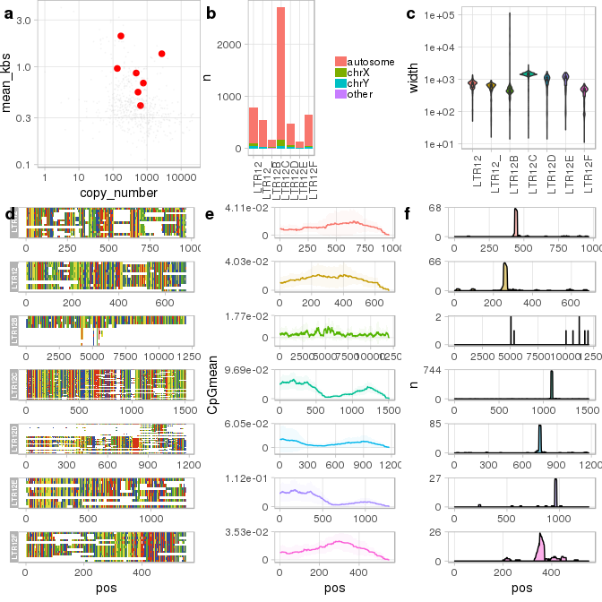

```r
gs <- plotTargets(gs) # generates, stores QC plots in guideSet and prints them to screen
```

```r
gs
```

[output not shown]

The output generates general statistics on selected families and optional information that requires a multiple sequence alignment (see `?plotTargets` for full annotation of the panels). As we can see from the figures, members of the LTR12C family are by far most prevalent and largest in size (panels **a** to **c**). Since we also calculated and added alignments, the output further visualizes the multiple sequence alignment (**d**), the density of CpG dinucleotides across it (**e**) and includes information on putative consensus transcription start sites (TSSs) (**f**). We can use this information for example, to optimize the design of our guideRNAs by targeting CpG dense regions close to the putative TSS.